# 1. LIMPIEZA Y TRANSFORMACION DE LOS DATOS

# 4. CLUSTERING ALGORITMO K-MEANS

## Eleccion de K

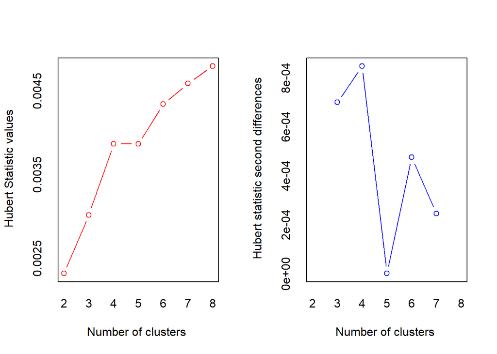

```
## *** : The Hubert index is a graphical method of determining the number of clusters.
##                 In the plot of Hubert index, we seek a significant knee that corresponds to a
##                 significant increase of the value of the measure i.e the significant peak in Hubert
##                 index second differences plot.
##
```

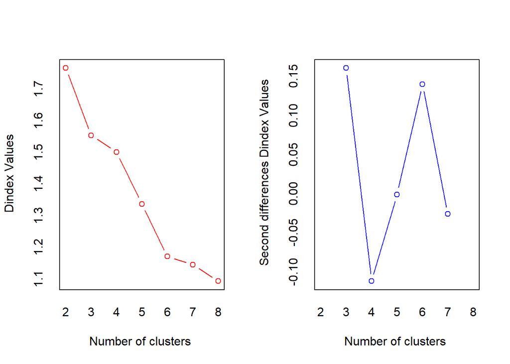

```
## *** : The D index is a graphical method of determining the number of clusters.
##                 In the plot of D index, we seek a significant knee (the significant peak in Dindex
##                 second differences plot) that corresponds to a significant increase of the value of
##                 the measure.
##
## * Among all indices:
## * 5 proposed 2 as the best number of clusters
## * 5 proposed 3 as the best number of clusters
## * 2 proposed 4 as the best number of clusters
## * 1 proposed 5 as the best number of clusters
## * 6 proposed 6 as the best number of clusters
## * 2 proposed 7 as the best number of clusters
## * 2 proposed 8 as the best number of clusters
##
##                    ***** Conclusion *****
##
## * According to the majority rule, the best number of clusters is  6
##
##
```

```r
#chunk4.1

# NÚMERO ÓPTIMO DE CLUSTERS - 4 MÉTODOS

# Usar solo las coordenadas de PCA para clustering
datos_cluster <- datos_pca_coord %>% select(-id)

# 1. MÉTODO DEL CODO (ELBOW)
# ============================================
set.seed(123)
wss <- numeric(10)
for(k in 1:10) {
  km_temp <- kmeans(datos_cluster, centers = k, nstart = 50, iter.max = 100)
  wss[k] <- km_temp$tot.withinss
}


# Encontrar punto de codo (método de la segunda derivada)
diff_wss <- diff(wss)
diff_diff_wss <- diff(diff_wss)
k_codo <- which.min(diff_diff_wss) + 1  # +1 por el desplazamiento

df_elbow <- data.frame(k = 1:10, wss = wss)

p_elbow <- ggplot(df_elbow, aes(x = k, y = wss)) +
  geom_line(color = "steelblue", size = 1) +
  geom_point(color = "steelblue", size = 3) +
  geom_vline(xintercept = k_codo, linetype = "dashed", color = "red", size = 1) +
  annotate("text", x = k_codo, y = min(wss),
           label = paste("k =", k_codo),
           color = "red", vjust = -0.5, size = 4) +
  labs(title = "Método del Codo",
       subtitle = paste("Punto de inflexión en k =", k_codo),
       x = "Número de Clusters (k)",
       y = "Suma de Cuadrados Intra-clusters") +
  theme_minimal() +
  theme(plot.subtitle = element_text(color = "red", face = "bold"))

# 2. MÉTODO DE LA SILUETA PROMEDIO
# ============================================
silhouette_scores <- numeric(9)
for(k in 2:10) {
  set.seed(123)
  km_temp <- kmeans(datos_cluster, centers = k, nstart = 50)
  sil <- silhouette(km_temp$cluster, dist(datos_cluster))
  silhouette_scores[k-1] <- mean(sil[, 3])
}

df_sil <- data.frame(k = 2:10, silhouette = silhouette_scores)
k_silueta <- df_sil$k[which.max(df_sil$silhouette)]

p_sil <- ggplot(df_sil, aes(x = k, y = silhouette)) +
  geom_line(color = "darkgreen", size = 1) +
  geom_point(color = "darkgreen", size = 3) +
  geom_vline(xintercept = k_silueta, linetype = "dashed", color = "red", size = 1) +
  annotate("text", x = k_silueta, y = max(df_sil$silhouette),
           label = paste("k =", k_silueta, "\n(", round(max(df_sil$silhouette), 3), ")"),
           color = "red", vjust = -0.5, size = 3.5) +
  geom_hline(yintercept = 0.5, linetype = "dotted", color = "orange", alpha = 0.7) +
  labs(title = "Método de la Silueta",
       subtitle = paste("Máxima silueta en k =", k_silueta),
       x = "Número de Clusters (k)",
       y = "Ancho de Silueta Promedio") +
  theme_minimal() +
  theme(plot.subtitle = element_text(color = "red", face = "bold"))

# 3. ESTADÍSTICO GAP
# ============================================
set.seed(123)
gap_stat <- clusGap(datos_cluster, FUN = kmeans, nstart = 50,
                    K.max = 10, B = 50)

# Extraer datos del gap statistic
gap_df <- data.frame(
  k = 1:10,
  gap = gap_stat$Tab[, "gap"],
  SE = gap_stat$Tab[, "SE.sim"]
)

# Encontrar k óptimo (método de Tibshirani)
k_gap <- with(gap_df, {
  for(i in 1:(nrow(gap_df)-1)) {
    if(gap[i] >= gap[i+1] - SE[i+1]) {
      return(i)
    }
  }
  return(which.max(gap))  # fallback
})

p_gap <- ggplot(gap_df, aes(x = k, y = gap)) +
  geom_line(color = "purple", size = 1) +
  geom_point(color = "purple", size = 3) +
  geom_errorbar(aes(ymin = gap - SE, ymax = gap + SE),
                width = 0.2, color = "gray50", alpha = 0.7) +
  geom_vline(xintercept = k_gap, linetype = "dashed", color = "red", size = 1) +
  annotate("text", x = k_gap, y = max(gap_df$gap),
           label = paste("k =", k_gap),
           color = "red", vjust = -0.5, size = 4) +
  labs(title = "Estadístico Gap",
       subtitle = paste("k óptimo =", k_gap, "(método Tibshirani)"),
       x = "Número de Clusters (k)",
       y = "Estadístico Gap") +
  theme_minimal() +
  theme(plot.subtitle = element_text(color = "red", face = "bold"))

# 4. NbClust (MÚLTIPLES ÍNDICES)
# ============================================
set.seed(123)
nbclust_result <- NbClust(datos_cluster, distance = "euclidean",
                          min.nc = 2, max.nc = 8,
                          method = "kmeans", index = "all")
```

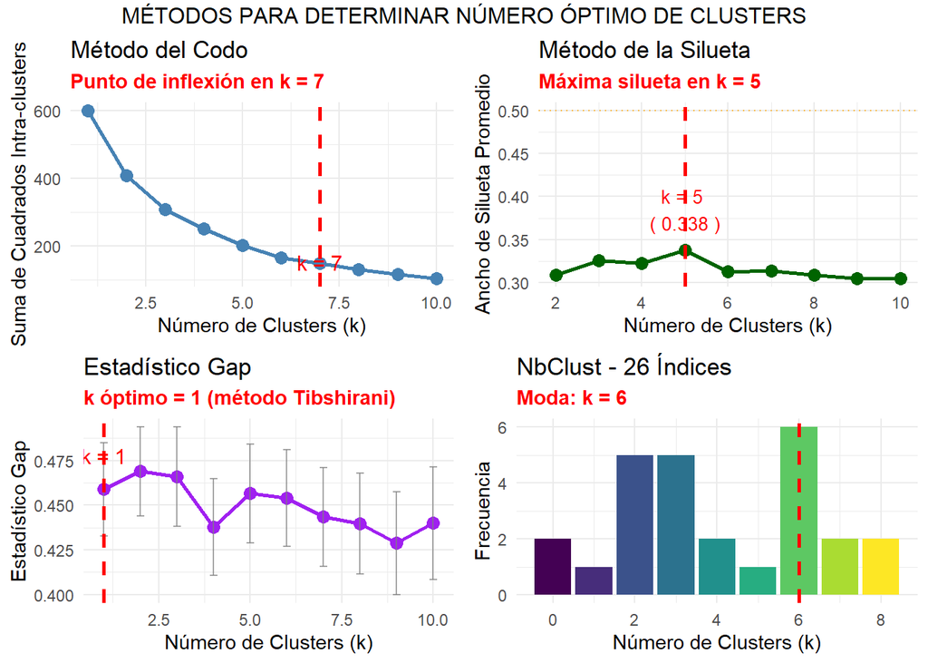

```r
# Tabla de frecuencias
frecuencias <- as.data.frame(table(nbclust_result$Best.nc[1,]))
names(frecuencias) <- c("k", "Frecuencia")
frecuencias$k <- as.numeric(as.character(frecuencias$k))

# Encontrar k más frecuente
k_nbclust <- frecuencias$k[which.max(frecuencias$Frecuencia)]

p_nbclust <- ggplot(frecuencias, aes(x = k, y = Frecuencia, fill = factor(k))) +
  geom_bar(stat = "identity") +
  geom_vline(xintercept = k_nbclust, linetype = "dashed", color = "red", size = 1) +
  annotate("text", x = k_nbclust, y = max(frecuencias$Frecuencia),
           label = paste("k =", k_nbclust, "\n(", max(frecuencias$Frecuencia), "índices)"),
           color = "red", vjust = -0.5, size = 3.5) +
  labs(title = "NbClust - 26 Índices",
       subtitle = paste("Moda: k =", k_nbclust),
       x = "Número de Clusters (k)",
       y = "Frecuencia") +
  theme_minimal() +
  scale_fill_viridis_d() +
  theme(plot.subtitle = element_text(color = "red", face = "bold"),
        legend.position = "none")

# VISUALIZACIÓN COMBINADA
# ============================================
grid.arrange(p_elbow, p_sil, p_gap, p_nbclust, ncol = 2, nrow = 2,
             top = "MÉTODOS PARA DETERMINAR NÚMERO ÓPTIMO DE CLUSTERS")
```

```r
# TABLA RESUMEN
# ============================================
tabla_resumen <- data.frame(
  Metodo = c("Método del Codo", "Silueta Promedio", "Estadístico Gap", "NbClust (moda)"),
  k_optimo = c(k_codo, k_silueta, k_gap, k_nbclust),
  Valor = c(round(wss[k_codo], 0),
            round(max(df_sil$silhouette), 3),
            round(max(gap_df$gap), 3),
            paste0(max(frecuencias$Frecuencia), "/26"))
)

cat("RESUMEN DE MÉTODOS PARA SELECCIÓN DE k\n")
```

```
## RESUMEN DE MÉTODOS PARA SELECCIÓN DE k
```

```r
cat("========================================\n")
print(tabla_resumen)
```

```
##             Metodo k_optimo Valor
## 1  Método del Codo        7   147
## 2 Silueta Promedio        5 0.338
## 3  Estadístico Gap        1 0.469
## 4   NbClust (moda)        6  6/26
```

```r
# DECISIÓN
# ============================================
k_mayoria <- as.numeric(names(sort(table(c(k_codo, k_silueta, k_gap, k_nbclust)),
                                   decreasing = TRUE)[1]))

cat("DECISIÓN FINAL\n")
```

```
## DECISIÓN FINAL
```

```r
cat("========================================\n")
cat("Resultados por método:\n")
```

```
## Resultados por método:
```

```r
cat("  • Método del Codo: k =", k_codo, "\n")
```

```
##   • Método del Codo: k = 7
```

```r
cat("  • Silueta Promedio: k =", k_silueta, "\n")
```

```
##   • Silueta Promedio: k = 5
```

```r
cat("  • Estadístico Gap: k =", k_gap, "\n")
```

```
##   • Estadístico Gap: k = 1
```

```r
cat("  • NbClust: k =", k_nbclust, "\n\n")
```

```
##   • NbClust: k = 6
```

Con esto se puede decir que la eleccion de tamaño de k ideal para la segmentación es un topico complejo puesto que se evaluan 4 metodos diferentes y estos arrojan resultados diferentes, por lo que no se llega a un consenso entre los metodos elegidos, mas sin emabrgo se considera que esta decision requiere de un *CRITERIO ANALITICO INFORMADO*, en este caso, es importante entender la esencia de cada uno de los metodos planteados para darles una importancia decisioria y entre los cuatro metodos de eleccion tenemos dos posibles soluciones al problema, optar por el metodo mas frecuente la literatura y el mas robusto el metodo silhouette, sin embargo en este caso como analistas nos inclinamos por el valor de k que arroja el NbClust, ya que este método permite evaluar simultáneamente múltiples índices de validación interna (hasta 30) y seleccionar el valor de k que presenta mayor concordancia entre dichos criterios, reduciendo la subjetividad asociada a la interpretación individual de cada método.

Sin embargo para dar mayor rigor metodologico en la eleccion se plantea una evaluacion completa del silhouette para los niveles k del 2 a 10

```r
#chunk4.2
# EVALUACIÓN COMPLETA DE SILHOUETTE PARA k = 2 a 10
# ============================================


cat("ANÁLISIS DE SILHOUETTE PARA DIFERENTES NÚMEROS DE CLUSTERS\n")
```

```
## ANÁLISIS DE SILHOUETTE PARA DIFERENTES NÚMEROS DE CLUSTERS
```

```r
cat("========================================================\n\n")
# Usar solo las coordenadas de PCA para clustering
datos_cluster <- datos_pca_coord %>% select(-id)

# Dataframe para almacenar resultados
resultados_silhouette <- data.frame(
  k = 2:10,
  silhouette_global = NA,
  min_silhouette = NA,
  max_silhouette = NA,
  sd_silhouette = NA,
  pct_mayor_05 = NA,
  pct_mayor_03 = NA,
  pct_negativos = NA,
  cluster1_size = NA,
  cluster2_size = NA,
  cluster3_size = NA,
  cluster4_size = NA,
  cluster5_size = NA,
  cluster6_size = NA,
  cluster7_size = NA,
  cluster8_size = NA,
  cluster9_size = NA,
  cluster10_size = NA,
  cluster1_sil = NA,
  cluster2_sil = NA,
  cluster3_sil = NA,
  cluster4_sil = NA,
  cluster5_sil = NA,
  cluster6_sil = NA,
  cluster7_sil = NA,
  cluster8_sil = NA,
  cluster9_sil = NA,
  cluster10_sil = NA
)

# Evaluar cada k
for(k in 2:10) {
  set.seed(123)  # Para reproducibilidad
  km_temp <- kmeans(datos_cluster, centers = k, nstart = 50, iter.max = 100)

  # Calcular silhouette
  dist_matrix <- dist(datos_cluster)
  sil_temp <- silhouette(km_temp$cluster, dist_matrix)
  sil_df <- as.data.frame(sil_temp[, 1:3])
  names(sil_df) <- c("cluster", "neighbor", "sil_width")

  # Estadísticas globales
  resultados_silhouette$silhouette_global[k-1] <- mean(sil_df$sil_width)
  resultados_silhouette$min_silhouette[k-1] <- min(sil_df$sil_width)
  resultados_silhouette$max_silhouette[k-1] <- max(sil_df$sil_width)
  resultados_silhouette$sd_silhouette[k-1] <- sd(sil_df$sil_width)

  # Tamaño de cada cluster
  tamaños <- table(km_temp$cluster)
  for(i in 1:length(tamaños)) {
    col_name <- paste0("cluster", i, "_size")
    if(col_name %in% names(resultados_silhouette)) {
      resultados_silhouette[k-1, col_name] <- tamaños[i]
    }
  }

  # Silhouette promedio por cluster
  sil_por_cluster <- aggregate(sil_width ~ cluster, data = sil_df, FUN = mean)
  for(i in 1:nrow(sil_por_cluster)) {
    col_name <- paste0("cluster", sil_por_cluster$cluster[i], "_sil")
    if(col_name %in% names(resultados_silhouette)) {
      resultados_silhouette[k-1, col_name] <- sil_por_cluster$sil_width[i]
    }
  }
}

# Mostrar resultados principales
cat(" RESUMEN DE SILHOUETTE POR NÚMERO DE CLUSTERS:\n")
```

```
##  RESUMEN DE SILHOUETTE POR NÚMERO DE CLUSTERS:
```

```r
cat("------------------------------------------------\n")
resultados_principales <- resultados_silhouette %>%
  select(k, silhouette_global, min_silhouette, max_silhouette,
         pct_mayor_05, pct_mayor_03, pct_negativos) %>%
  mutate(
    silhouette_global = round(silhouette_global, 3),
    min_silhouette = round(min_silhouette, 3),
    max_silhouette = round(max_silhouette, 3),

  )

print(resultados_principales)
```

```
##    k silhouette_global min_silhouette max_silhouette pct_mayor_05 pct_mayor_03
## 1  2             0.309         -0.109          0.547           NA           NA
## 2  3             0.326         -0.088          0.605           NA           NA
## 3  4             0.323         -0.099          0.632           NA           NA
## 4  5             0.338         -0.066          0.602           NA           NA
## 5  6             0.313         -0.054          0.590           NA           NA
## 6  7             0.314         -0.111          0.603           NA           NA
## 7  8             0.309         -0.053          0.560           NA           NA
## 8  9             0.305         -0.059          0.866           NA           NA
## 9 10             0.305         -0.071          0.858           NA           NA
##   pct_negativos
## 1            NA
## 2            NA
## 3            NA
## 4            NA
## 5            NA
## 6            NA
## 7            NA
## 8            NA
## 9            NA
```

```r
# INTERPRETACIÓN DE RESULTADOS
# ============================================

cat("\n\n INTERPRETACIÓN DE LA CALIDAD:\n")
```

```
##
##
##  INTERPRETACIÓN DE LA CALIDAD:
```

```r
cat("--------------------------------\n")
cat("• Silhouette > 0.5: Excelente (clusters bien separados)\n")
```

```
## • Silhouette > 0.5: Excelente (clusters bien separados)
```

```r
cat("• Silhouette 0.3 - 0.5: Bueno (estructura razonable)\n")
```

```
## • Silhouette 0.3 - 0.5: Bueno (estructura razonable)
```

```r
cat("• Silhouette 0.2 - 0.3: Aceptable (posible superposición)\n")
```

```
## • Silhouette 0.2 - 0.3: Aceptable (posible superposición)
```

```r
cat("• Silhouette < 0.2: Débil (clusters no bien definidos)\n\n")
```

```
## • Silhouette < 0.2: Débil (clusters no bien definidos)
```

```r
# Identificar mejor k por silhouette
mejor_k_sil <- resultados_principales$k[which.max(resultados_principales$silhouette_global)]
cat(" Mejor k por silhouette global: k =", mejor_k_sil,
    "(silhouette =", max(resultados_principales$silhouette_global), ")\n")
```

```
##  Mejor k por silhouette global: k = 5 (silhouette = 0.338 )
```

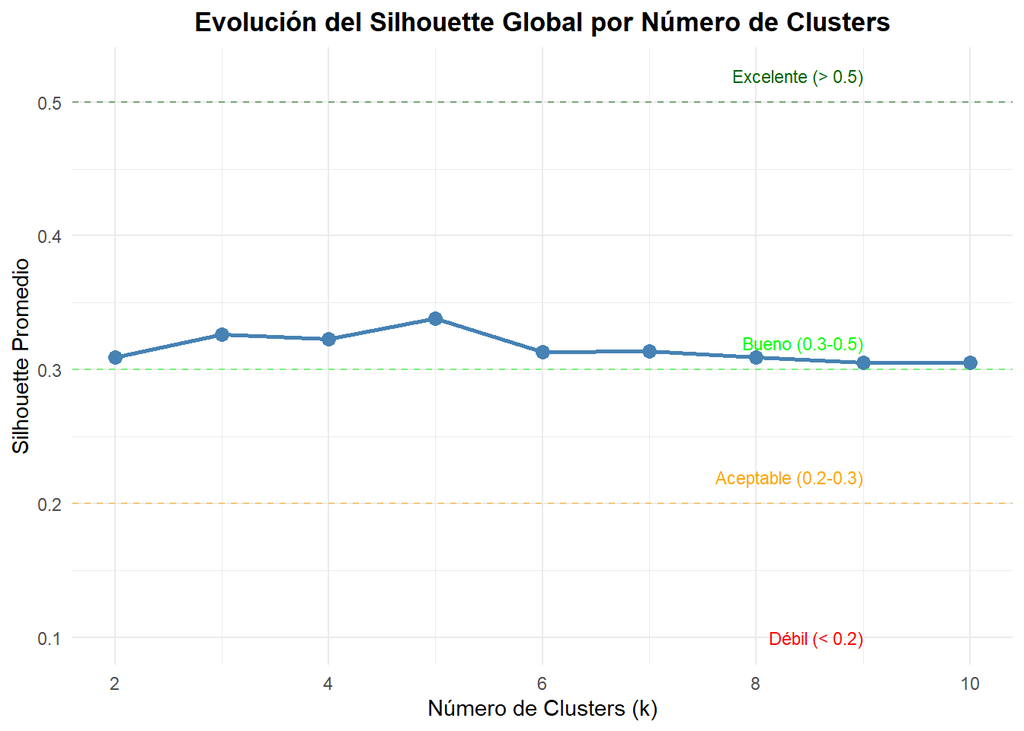

```r
# VISUALIZACIÓN DE SILHOUETTE POR K
# ============================================

# Gráfico de evolución del silhouette
p_evolucion <- ggplot(resultados_principales, aes(x = k, y = silhouette_global)) +
  geom_line(color = "steelblue", size = 1) +
  geom_point(color = "steelblue", size = 3) +
  geom_hline(yintercept = c(0.2, 0.3, 0.5), linetype = "dashed",
             color = c("orange", "green", "darkgreen"), alpha = 0.5) +
  annotate("text", x = 9, y = 0.52, label = "Excelente (> 0.5)",
           color = "darkgreen", size = 3, hjust = 1) +
  annotate("text", x = 9, y = 0.32, label = "Bueno (0.3-0.5)",
           color = "green", size = 3, hjust = 1) +
  annotate("text", x = 9, y = 0.22, label = "Aceptable (0.2-0.3)",
           color = "orange", size = 3, hjust = 1) +
  annotate("text", x = 9, y = 0.1, label = "Débil (< 0.2)",
           color = "red", size = 3, hjust = 1) +
  labs(title = "Evolución del Silhouette Global por Número de Clusters",
       x = "Número de Clusters (k)",
       y = "Silhouette Promedio") +
  theme_minimal() +
  theme(plot.title = element_text(face = "bold", hjust = 0.5))

print(p_evolucion)
```

```r
# DETALLE POR CLUSTER PARA CADA K
# ============================================

cat("\n\n DETALLE POR CLUSTER PARA CADA K:\n")
```

```
##
##
##  DETALLE POR CLUSTER PARA CADA K:
```

```r
cat("------------------------------------\n")
for(k in 2:min(6, 10)) {  # Mostrar hasta k=6 para no saturar
  cat("\n🔹 k =", k, ":\n")

  # Tamaños
  tamaños <- c()
  sil_values <- c()
  for(i in 1:k) {
    size_col <- paste0("cluster", i, "_size")
    sil_col <- paste0("cluster", i, "_sil")

    if(size_col %in% names(resultados_silhouette) &&
       !is.na(resultados_silhouette[k-1, size_col])) {
      tamaños[i] <- resultados_silhouette[k-1, size_col]
      sil_values[i] <- resultados_silhouette[k-1, sil_col]
    }
  }

  for(i in 1:k) {
    cat("   Cluster", i, ": tamaño =", tamaños[i],
        "| silhouette =", round(sil_values[i], 3))

    # Calificación cualitativa
    if(sil_values[i] > 0.5) {
      cat(" (Excelente)\n")
    } else if(sil_values[i] > 0.3) {
      cat(" (Bueno)\n")
    } else if(sil_values[i] > 0.2) {
      cat(" (Aceptable)\n")
    } else {
      cat(" (Débil)\n")
    }
  }
}
```

```
##
## 🔹 k = 2 :
##    Cluster 1 : tamaño = 49 | silhouette = 0.388 (Bueno)
##    Cluster 2 : tamaño = 50 | silhouette = 0.231 (Aceptable)
##
## 🔹 k = 3 :
##    Cluster 1 : tamaño = 44 | silhouette = 0.26 (Aceptable)
##    Cluster 2 : tamaño = 41 | silhouette = 0.432 (Bueno)
##    Cluster 3 : tamaño = 14 | silhouette = 0.222 (Aceptable)
##
## 🔹 k = 4 :
##    Cluster 1 : tamaño = 23 | silhouette = 0.153 (Débil)
##    Cluster 2 : tamaño = 33 | silhouette = 0.422 (Bueno)
##    Cluster 3 : tamaño = 36 | silhouette = 0.342 (Bueno)
##    Cluster 4 : tamaño = 7 | silhouette = 0.312 (Bueno)
##
## 🔹 k = 5 :
##    Cluster 1 : tamaño = 9 | silhouette = 0.229 (Aceptable)
##    Cluster 2 : tamaño = 7 | silhouette = 0.297 (Aceptable)
##    Cluster 3 : tamaño = 34 | silhouette = 0.339 (Bueno)
##    Cluster 4 : tamaño = 26 | silhouette = 0.312 (Bueno)
##    Cluster 5 : tamaño = 23 | silhouette = 0.418 (Bueno)
##
## 🔹 k = 6 :
##    Cluster 1 : tamaño = 22 | silhouette = 0.387 (Bueno)
##    Cluster 2 : tamaño = 11 | silhouette = 0.14 (Débil)
##    Cluster 3 : tamaño = 7 | silhouette = 0.304 (Bueno)
##    Cluster 4 : tamaño = 7 | silhouette = 0.236 (Aceptable)
##    Cluster 5 : tamaño = 27 | silhouette = 0.361 (Bueno)
##    Cluster 6 : tamaño = 25 | silhouette = 0.294 (Aceptable)
```

```r
# EXPORTAR DATAFRAME COMPLETO
# ============================================

# Guardar dataframe completo
write.csv(resultados_silhouette, "resultados_silhouette_completo.csv", row.names = FALSE)

cat("\n\n Dataframe guardado como 'resultados_silhouette_completo.csv'\n")
```

```
##
##
##  Dataframe guardado como 'resultados_silhouette_completo.csv'
```

```r
cat("   Contiene:", ncol(resultados_silhouette), "columnas con estadísticas detalladas\n")
```

```
##    Contiene: 28 columnas con estadísticas detalladas
```

```r
# RECOMENDACIÓN FINAL BASADA EN SILHOUETTE
# ============================================

cat("RECOMENDACIÓN PARA SELECCIÓN DE k\n")
```

```
## RECOMENDACIÓN PARA SELECCIÓN DE k
```

```r
cat("========================================================\n")
# Encontrar k con mejor silhouette entre 2 y 5 (rango comercialmente útil)
k_comerciales <- 3:4
k_comerciales_validos <- k_comerciales[k_comerciales <= max(resultados_principales$k)]
sil_comerciales <- resultados_principales$silhouette_global[
  resultados_principales$k %in% k_comerciales_validos
]

if(length(sil_comerciales) > 0) {
  mejor_k_comercial <- k_comerciales_validos[which.max(sil_comerciales)]
  cat("\n Considerando utilidad comercial (k entre 3 y 5):\n")
  cat("   Mejor opción: k =", mejor_k_comercial,
      "(silhouette =", round(max(sil_comerciales), 3), ")\n\n")

  # Comparar con el mejor estadístico puro
  if(mejor_k_comercial != mejor_k_sil) {
    cat("  Trade-off:\n")
    cat("   • Comercialmente útil: k =", mejor_k_comercial, "\n")
    cat("\n Recomendación: Usar k =", mejor_k_sil,
        "(balance entre calidad estadística y utilidad comercial)\n")
  } else {
    cat(" Coincidencia: El mejor k estadístico también es comercialmente útil\n")
  }
}
```

[output not shown]

Gracias al analisis realizado la eleccion se hace mas robusta y se define k=5 como k ideal para la clusterizacion

```r
#chun4.3
k_final <- mejor_k_sil  # Basado en decision

set.seed(123)
kmeans_final <- kmeans(datos_cluster, centers = k_final, nstart = 50, iter.max = 100)

# Añadir clusters al dataset
datos_pca_coord$cluster <- kmeans_final$cluster

# Tamaño de clusters
table(datos_pca_coord$cluster)
```

```
##
##  1  2  3  4  5
##  9  7 34 26 23
```

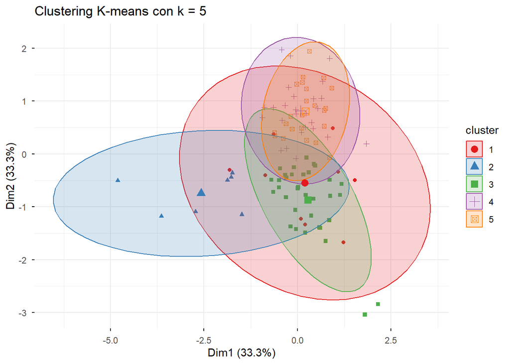

```r
# Visualización
fviz_cluster(kmeans_final, data = datos_cluster,
             geom = "point", ellipse.type = "norm",
             palette = "Set1", ggtheme = theme_minimal(),
             title = paste("Clustering K-means con k =", k_final))
```

## Validacion avanzada de estabilidad: metodo bootstrap

```r
#chunk4.4
# VALIDACIÓN DE CLUSTERS CON BOOTSTRAP
# ============================================

cat("VALIDACIÓN DE CLUSTERS CON BOOTSTRAP\n")
```

```
## VALIDACIÓN DE CLUSTERS CON BOOTSTRAP
```

```r
cat("========================================================\n\n")
# 1. BOOTSTRAP PARA EVALUAR ESTABILIDAD
# ========================================

set.seed(123)
n_bootstrap <- 100
k_candidatos <- 2:6

estabilidad <- matrix(0, nrow = length(k_candidatos), ncol = 2)
colnames(estabilidad) <- c("k", "estabilidad_promedio")
estabilidad[, "k"] <- k_candidatos

cat(" Evaluando estabilidad de clusters con", n_bootstrap, "remuestreos...\n")
```

```
##  Evaluando estabilidad de clusters con 100 remuestreos...
```

```r
for(i in seq_along(k_candidatos)) {
  k <- k_candidatos[i]
  indices_ajustados <- numeric(n_bootstrap)

  for(b in 1:n_bootstrap) {
    muestra_boot <- sample(1:nrow(datos_cluster),
                          size = nrow(datos_cluster),
                          replace = TRUE)

    km_boot <- kmeans(datos_cluster[muestra_boot, ],
                      centers = k,
                      nstart = 50,
                      iter.max = 100)

    if(k > 1) {
      dist_boot <- dist(datos_cluster[muestra_boot, ])
      sil_boot <- silhouette(km_boot$cluster, dist_boot)
      indices_ajustados[b] <- mean(sil_boot[, 3])
    }
  }

  estabilidad[i, "estabilidad_promedio"] <- mean(indices_ajustados, na.rm = TRUE)
  cat("  k =", k, ": estabilidad promedio =",
      round(estabilidad[i, "estabilidad_promedio"], 3), "\n")
}
```

```
##   k = 2 : estabilidad promedio = 0.337
##   k = 3 : estabilidad promedio = 0.35
##   k = 4 : estabilidad promedio = 0.372
##   k = 5 : estabilidad promedio = 0.379
##   k = 6 : estabilidad promedio = 0.381
```

```r
# 2. SILUETA PROMEDIO EN DATOS COMPLETOS
# =========================================

silueta_completa <- numeric(length(k_candidatos))

for(i in seq_along(k_candidatos)) {
  k <- k_candidatos[i]
  set.seed(123)
  km_temp <- kmeans(datos_cluster, centers = k, nstart = 50, iter.max = 100)
  sil_temp <- silhouette(km_temp$cluster, dist(datos_cluster))
  silueta_completa[i] <- mean(sil_temp[, 3])
}

# 3. INERCIA RELATIVA
# =====================

wss_valores <- numeric(length(k_candidatos))

for(i in seq_along(k_candidatos)) {
  k <- k_candidatos[i]
  set.seed(123)
  km_temp <- kmeans(datos_cluster, centers = k, nstart = 50, iter.max = 100)
  wss_valores[i] <- km_temp$tot.withinss
}

mejora_relativa <- c(NA, 1 - (wss_valores[-1] / wss_valores[-length(wss_valores)]))

# 4. TABLA COMPARATIVA
# ======================

resultados_validacion <- data.frame(
  k = k_candidatos,
  silueta = round(silueta_completa, 3),
  estabilidad_bootstrap = round(estabilidad[, "estabilidad_promedio"], 3),
  inercia_total = round(wss_valores, 0),
  mejora_relativa = round(mejora_relativa * 100, 1)
)

cat("\n RESULTADOS COMPARATIVOS PARA k = 2 A 6\n")
```

```
##
##  RESULTADOS COMPARATIVOS PARA k = 2 A 6
```

```r
cat("========================================================\n")
print(resultados_validacion)
```

```
##   k silueta estabilidad_bootstrap inercia_total mejora_relativa
## 1 2   0.309                 0.337           409              NA
## 2 3   0.326                 0.350           308            24.7
## 3 4   0.323                 0.372           251            18.6
## 4 5   0.338                 0.379           201            20.0
## 5 6   0.313                 0.381           166            17.4
```

```r
# 5. IDENTIFICAR CANDIDATOS (SOLO INFORMATIVO, SIN DECISIÓN)
# ============================================================

cat("\n CANDIDATOS SEGÚN CADA CRITERIO:\n")
```

```
##
##  CANDIDATOS SEGÚN CADA CRITERIO:
```

```r
cat("========================================================\n\n")
k_silueta <- k_candidatos[which.max(silueta_completa)]
k_estable <- k_candidatos[which.max(estabilidad[, "estabilidad_promedio"])]
puntos_codo <- which(mejora_relativa > 10)
k_codo <- if(length(puntos_codo) > 0) max(puntos_codo) else NA

cat("  • Máxima silueta (calidad): k =", k_silueta,
    "(valor =", round(max(silueta_completa), 3), ")\n")
```

```
##   • Máxima silueta (calidad): k = 5 (valor = 0.338 )
```

```r
cat("  • Máxima estabilidad bootstrap: k =", k_estable,
    "(valor =", round(max(estabilidad[, "estabilidad_promedio"]), 3), ")\n")
```

```
##   • Máxima estabilidad bootstrap: k = 6 (valor = 0.381 )
```

```r
if(!is.na(k_codo)) {
  cat("  • Punto de codo: k =", k_codo, "\n")
} else {
  cat("  • Punto de codo: No identificado claramente\n")
}
```

```
##   • Punto de codo: No identificado claramente
```

```r
# 6. TAMAÑO DE CLUSTERS PARA CADA k
# ===================================

cat("\n TAMAÑO DE CLUSTERS POR k:\n")
```

```
##
##  TAMAÑO DE CLUSTERS POR k:
```

```r
cat("========================================================\n")
for(k in k_candidatos) {
  set.seed(123)
  km_temp <- kmeans(datos_cluster, centers = k, nstart = 50, iter.max = 100)
  tamanos <- table(km_temp$cluster)

  cat("\n  k =", k, ":\n")
  for(i in 1:length(tamanos)) {
    cat("    Cluster", i, ":", tamanos[i], "subdistribuidores\n")
  }
}
```

```
##
##   k = 2 :
##     Cluster 1 : 49 subdistribuidores
##     Cluster 2 : 50 subdistribuidores
##
##   k = 3 :
##     Cluster 1 : 44 subdistribuidores
##     Cluster 2 : 41 subdistribuidores
##     Cluster 3 : 14 subdistribuidores
##
##   k = 4 :
##     Cluster 1 : 23 subdistribuidores
##     Cluster 2 : 33 subdistribuidores
##     Cluster 3 : 36 subdistribuidores
##     Cluster 4 : 7 subdistribuidores
##
##   k = 5 :
##     Cluster 1 : 9 subdistribuidores
##     Cluster 2 : 7 subdistribuidores
##     Cluster 3 : 34 subdistribuidores
##     Cluster 4 : 26 subdistribuidores
##     Cluster 5 : 23 subdistribuidores
##
##   k = 6 :
##     Cluster 1 : 22 subdistribuidores
##     Cluster 2 : 11 subdistribuidores
##     Cluster 3 : 7 subdistribuidores
##     Cluster 4 : 7 subdistribuidores
##     Cluster 5 : 27 subdistribuidores
##     Cluster 6 : 25 subdistribuidores
```

[figure not shown]

```r
# 7. VISUALIZACIÓN DE TRADE-OFF
# ===============================

df_tradeoff <- resultados_validacion %>%
  select(k, silueta, estabilidad_bootstrap) %>%
  pivot_longer(cols = -k, names_to = "metrica", values_to = "valor")

p_tradeoff <- ggplot(df_tradeoff, aes(x = k, y = valor, color = metrica, group = metrica)) +
  geom_line(size = 1) +
  geom_point(size = 3) +
  scale_color_manual(values = c("silueta" = "darkgreen", "estabilidad_bootstrap" = "purple"),
                     labels = c("Silueta promedio", "Estabilidad Bootstrap")) +
  labs(title = "Trade-off: Calidad vs Estabilidad por Número de Clusters",
       x = "Número de Clusters (k)",
       y = "Valor de la métrica",
       color = "Métrica") +
  theme_minimal() +
  theme(plot.title = element_text(face = "bold", hjust = 0.5),
        legend.position = "bottom")

print(p_tradeoff)
```

```r
# 8. NOTA SOBRE LA DECISIÓN
# ===========================

cat("\n\n========================================================\n")
cat(" NOTA SOBRE LA SELECCIÓN DE k\n")
```

```
##  NOTA SOBRE LA SELECCIÓN DE k
```

```r
cat("========================================================\n\n")
cat(" Los criterios estadísticos sugieren diferentes valores de k:\n")
```

```
##  Los criterios estadísticos sugieren diferentes valores de k:
```

```r
cat("   • Silueta maximiza en k =", k_silueta, "\n")
```

```
##    • Silueta maximiza en k = 5
```

```r
cat("   • Estabilidad bootstrap maximiza en k =", k_estable, "\n")
```

```
##    • Estabilidad bootstrap maximiza en k = 6
```

```r
cat("   • Punto de codo sugiere k =", ifelse(!is.na(k_codo), k_codo, "no definido"), "\n")
```

```
##    • Punto de codo sugiere k = no definido
```

```r
cat("\n La decisión final debe considerar:\n")
```

```
##
##  La decisión final debe considerar:
```

```r
cat("   • Calidad estadística (silueta)\n")
```

```
##    • Calidad estadística (silueta)
```

```r
cat("   • Estabilidad ante remuestreo (bootstrap)\n")
```

```
##    • Estabilidad ante remuestreo (bootstrap)
```

```r
cat("   • Viabilidad comercial (tamaño mínimo de clusters)\n")
```

```
##    • Viabilidad comercial (tamaño mínimo de clusters)
```

```r
cat("   • Interpretabilidad de los segmentos\n")
```

```
##    • Interpretabilidad de los segmentos
```

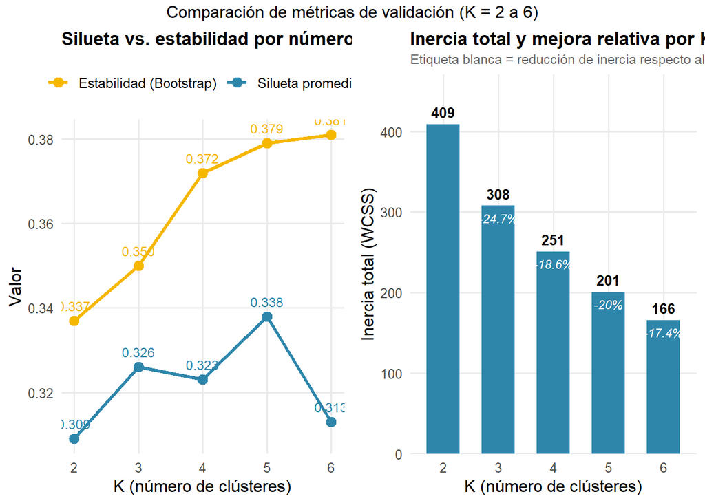

```r
#chunk_comparacion_k
# ============================================
# Visualización comparativa: Silueta, Estabilidad Bootstrap e Inercia por K
# ============================================

library(tidyr)

resultados_k <- data.frame(
  k = 2:6,
  silueta = c(0.309, 0.326, 0.323, 0.338, 0.313),
  estabilidad_bootstrap = c(0.337, 0.350, 0.372, 0.379, 0.381),
  inercia_total = c(409, 308, 251, 201, 166),
  mejora_relativa = c(NA, 24.7, 18.6, 20.0, 17.4)
)

# --- Gráfico 1: Silueta vs. Estabilidad Bootstrap (líneas superpuestas) ---
df_lineas <- resultados_k %>%
  select(k, silueta, estabilidad_bootstrap) %>%
  pivot_longer(cols = c(silueta, estabilidad_bootstrap),
               names_to = "metrica", values_to = "valor") %>%
  mutate(metrica = case_when(
    metrica == "silueta" ~ "Silueta promedio",
    metrica == "estabilidad_bootstrap" ~ "Estabilidad (Bootstrap)"
  ))

p_metricas <- ggplot(df_lineas, aes(x = k, y = valor, color = metrica, group = metrica)) +
  geom_line(linewidth = 1.1) +
  geom_point(size = 3) +
  geom_text(aes(label = sprintf("%.3f", valor)), vjust = -1, size = 3.3, show.legend = FALSE) +
  scale_x_continuous(breaks = 2:6) +
  scale_color_manual(values = c("Silueta promedio" = "#2E86AB", "Estabilidad (Bootstrap)" = "#F5B700")) +
  labs(title = "Silueta vs. estabilidad por número de clústeres",
       x = "K (número de clústeres)", y = "Valor", color = NULL) +
  theme_minimal(base_size = 12) +
  theme(
    plot.title = element_text(size = 13, face = "bold", margin = margin(b = 10)),
    legend.position = "top",
    panel.grid.minor = element_blank()
  )

# --- Gráfico 2: Inercia total con mejora relativa etiquetada ---
p_inercia <- ggplot(resultados_k, aes(x = factor(k), y = inercia_total)) +
  geom_col(fill = "#2E86AB", alpha = 1, width = 0.6) +
  geom_text(aes(label = inercia_total), vjust = -0.6, size = 3.5, fontface = "bold") +
  geom_text(
    data = subset(resultados_k, !is.na(mejora_relativa)),
    aes(label = paste0("-", mejora_relativa, "%")),
    vjust = 1.8, size = 3.2, color = "white", fontface = "italic"
  ) +
  scale_y_continuous(expand = expansion(mult = c(0, 0.15))) +
  labs(title = "Inercia total y mejora relativa por K",
       subtitle = "Etiqueta blanca = reducción de inercia respecto al K anterior",
       x = "K (número de clústeres)", y = "Inercia total (WCSS)") +
  theme_minimal(base_size = 12) +
  theme(
    plot.title = element_text(size = 13, face = "bold", margin = margin(b = 4)),
    plot.subtitle = element_text(size = 9.5, color = "grey40"),
    panel.grid.minor = element_blank()
  )

library(gridExtra)
grid_comparacion <- grid.arrange(p_metricas, p_inercia, ncol = 2,
                                   top = "Comparación de métricas de validación (K = 2 a 6)")
```

```r
print(grid_comparacion)
```

```r
ggsave("graficos_distribuciones/comparacion_metricas_k.png",
       grid_comparacion, width = 13, height = 5.5, dpi = 300, bg = "white")
```

```r
#chunk_tabla_comparacion_k
# ============================================
# Tabla formateada: Comparación de métricas por K
# ============================================

library(kableExtra)

resultados_k <- data.frame(
  K = 2:6,
  Silueta = c(0.309, 0.326, 0.323, 0.338, 0.313),
  `Estabilidad (Bootstrap)` = c(0.337, 0.350, 0.372, 0.379, 0.381),
  `Inercia total` = c(409, 308, 251, 201, 166),
  `Mejora relativa (%)` = c(NA, 24.7, 18.6, 20.0, 17.4),
  check.names = FALSE
)

resultados_k %>%
  kable(caption = "Comparación de métricas de validación interna por número de clústeres (K)",
        align = "c", digits = 3, na = "—") %>%
  kable_styling(bootstrap_options = c("striped", "hover", "condensed"), full_width = FALSE) %>%
  row_spec(4, bold = TRUE, background = "#EAF3EC") %>%  # resalta K=5, el valor de silueta más alto
  column_spec(1, bold = TRUE)
```

Comparación de métricas de validación interna por número de clústeres (K)

| K | Silueta | Estabilidad (Bootstrap) | Inercia total | Mejora relativa (%) |
| --- | --- | --- | --- | --- |
| 2 | 0.309 | 0.337 | 409 | NA |
| 3 | 0.326 | 0.350 | 308 | 24.7 |
| 4 | 0.323 | 0.372 | 251 | 18.6 |
| 5 | 0.338 | 0.379 | 201 | 20.0 |
| 6 | 0.313 | 0.381 | 166 | 17.4 |

Segun los resultados, despues de usar el metodo del bootstrap para evaluar la estabilidad de los clusters, se observa que el valor de k=5 presenta una estabilidad promedio razonable 0.379, lo que sugiere que esta segmentación es robusta ante variaciones en los datos. Pero, considerando que la elección de K fue arbitraria, desde un razonamiento basado en la eficiencia k=4 presenta una estabilidad promedio SIMILAR o CERCANA de 0.372 vs 0.379 y segun la tesis de Dolnicar (2002) un analisis de cluster menor podria generar valor desde la viabilidad comercial, por lo que a la hora de realizar una estrategia comercial, esta decision desperdiciaria la menor cantidad de recursos por ello se decide analizar el comportamiento de los datos en k=4 como forma de validacion interna

AUNQUE SE ELIGE K=6 COMO VALOR OPTIMO DE NUMERO DE CLUSTERES PARA LA SEGMENTACION GRACIAS AL ANALISIS QUE ARROJO EL BOOTSTRAP, SE HACE TAMBIEM UN ANALISIS CON K=4 PARA TENER UNA VISION MAS AMPLIA DE LOS RESULTADOS Y VER SI SE OBTIENEN CLUSTERES CON CARACTERISTICAS COMERCIALES DISTINTAS,

## Analisis de sensibilidad del k optimo (evaluamos k=4 y k=6 )

```r
# chunk4.5
# ANÁLISIS DE SENSIBILIDAD - ESCENARIO k = 4
# ============================================

cat(" ANÁLISIS DE SENSIBILIDAD: ESCENARIO k = 4\n")
```

```
##  ANÁLISIS DE SENSIBILIDAD: ESCENARIO k = 4
```

```r
cat("========================================================\n\n")
cat("   • k = 4 agrupa los subdistribuidores en 4 perfiles diferenciados\n")
```

```
##    • k = 4 agrupa los subdistribuidores en 4 perfiles diferenciados
```

```r
cat("   • Permite estrategias comerciales específicas por nicho\n\n")
```

```
##    • Permite estrategias comerciales específicas por nicho
```

```r
# 1. APLICAR K-MEANS CON k = 4
set.seed(123)
k4_final <- kmeans(datos_cluster, centers = 4, nstart = 100, iter.max = 100)

# 2. CALCULAR SILHOUETTE
dist_matrix <- dist(datos_cluster)
sil_k4 <- silhouette(k4_final$cluster, dist_matrix)
sil_promedio_k4 <- mean(sil_k4[, 3])

cat(" RESULTADOS PARA k = 4:\n")
```

```
##  RESULTADOS PARA k = 4:
```

```r
cat("-------------------------\n")
cat("   • Silueta promedio:", round(sil_promedio_k4, 4), "\n")
```

```
##    • Silueta promedio: 0.3225
```

```r
cat("   • Calidad: ",
    ifelse(sil_promedio_k4 > 0.5, "EXCELENTE",
           ifelse(sil_promedio_k4 > 0.3, "BUENA",
                  ifelse(sil_promedio_k4 > 0.2, "ACEPTABLE", "DÉBIL"))), "\n\n")
```

```
##    • Calidad:  BUENA
```

```r
# 3. TAMAÑO DE CLUSTERS
cat(" TAMAÑO DE LOS 4 CLUSTERS:\n")
```

```
##  TAMAÑO DE LOS 4 CLUSTERS:
```

```r
for(i in 1:4) {
  tamaño <- sum(k4_final$cluster == i)
  porcentaje <- round(tamaño / length(k4_final$cluster) * 100, 1)
  cat("   • Cluster", i, ":", tamaño, "subdistribuidores (", porcentaje, "%)\n")
}
```

```
##    • Cluster 1 : 23 subdistribuidores ( 23.2 %)
##    • Cluster 2 : 33 subdistribuidores ( 33.3 %)
##    • Cluster 3 : 36 subdistribuidores ( 36.4 %)
##    • Cluster 4 : 7 subdistribuidores ( 7.1 %)
```

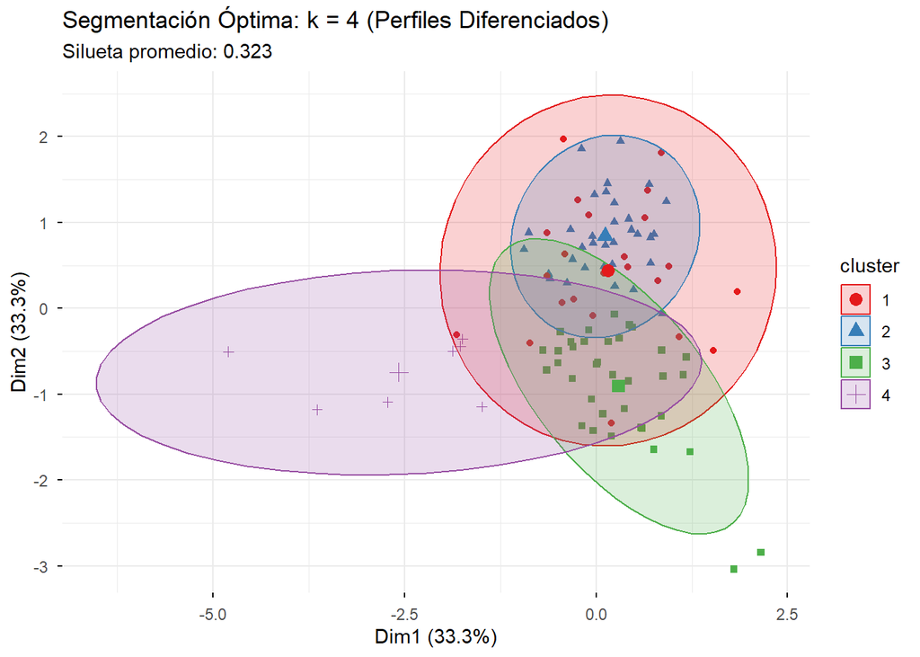

```r
# 4. VISUALIZACIÓN
p_k4 <- fviz_cluster(k4_final, data = datos_cluster,
                     geom = "point",
                     ellipse.type = "norm",
                     palette = "Set1",
                     ggtheme = theme_minimal(),
                     main = "Segmentación Óptima: k = 4 (Perfiles Diferenciados)",
                     subtitle = paste("Silueta promedio:", round(sil_promedio_k4, 3)))

print(p_k4)
```

```r
# 5. ESTADÍSTICAS POR CLUSTER
cat("\n\n========================================================\n")
cat(" CARACTERÍSTICAS PROMEDIO POR CLUSTER (k=4)\n")
```

```
##  CARACTERÍSTICAS PROMEDIO POR CLUSTER (k=4)
```

```r
cat("========================================================\n")
datos_temp <- datos_completos
datos_temp$cluster_k4 <- k4_final$cluster

vars_comparar <- c("n_empleados", "n_clientes", "ventas_mes",
                   "compra_mensual_num", "num_lineas")

cat("\n RESULTADOS POR CLUSTER:\n")
```

```
##
##  RESULTADOS POR CLUSTER:
```

```r
cat("-------------------------\n")
for(var in intersect(vars_comparar, names(datos_temp))) {
  cat("\n", var, ":\n")
  stats <- datos_temp %>%
    group_by(cluster_k4) %>%
    summarise(media = round(mean(.data[[var]], na.rm = TRUE), 1),
              mediana = round(median(.data[[var]], na.rm = TRUE), 1),
              n = n())

  for(i in 1:4) {
    cat("   Cluster", i, ": media =", stats$media[i],
        "| mediana =", stats$mediana[i], "\n")
  }
}
```

```
##
##  n_empleados :
##    Cluster 1 : media = 3.3 | mediana = 3
##    Cluster 2 : media = 2.4 | mediana = 2
##    Cluster 3 : media = 4.8 | mediana = 5
##    Cluster 4 : media = 3.7 | mediana = 3
##
##  n_clientes :
##    Cluster 1 : media = 179.6 | mediana = 150
##    Cluster 2 : media = 86.6 | mediana = 70
##    Cluster 3 : media = 192.9 | mediana = 200
##    Cluster 4 : media = 87.1 | mediana = 60
##
##  ventas_mes :
##    Cluster 1 : media = 321.3 | mediana = 250
##    Cluster 2 : media = 127.9 | mediana = 110
##    Cluster 3 : media = 418.9 | mediana = 350
##    Cluster 4 : media = 145.1 | mediana = 130
##
##  compra_mensual_num :
##    Cluster 1 : media = 3 | mediana = 3
##    Cluster 2 : media = 2.5 | mediana = 3
##    Cluster 3 : media = 4.3 | mediana = 4
##    Cluster 4 : media = 4.9 | mediana = 5
##
##  num_lineas :
##    Cluster 1 : media = 1.9 | mediana = 1
##    Cluster 2 : media = 1.8 | mediana = 1
##    Cluster 3 : media = 3.6 | mediana = 4
##    Cluster 4 : media = 3.1 | mediana = 3
```

```r
# 6. PERFILES COMERCIALES IDENTIFICADOS
cat("\n PERFILES COMERCIALES POR CLUSTER (k=4)\n")
```

```
##
##  PERFILES COMERCIALES POR CLUSTER (k=4)
```

```r
cat("========================================================\n")
order_clusters <- order(table(k4_final$cluster), decreasing = TRUE)
centroides <- as.data.frame(k4_final$centers)
centroides$cluster <- 1:4

# Tabla de centroides K=4 en el espacio PCA (Dim1/Dim2/Dim3)
centroides_k4 <- as.data.frame(k4_final$centers)
colnames(centroides_k4) <- c("Dim1_escala_volumen", "Dim2_satisfaccion", "Dim3_antiguedad_dinamismo")
centroides_k4$cluster <- 1:4
print(centroides_k4)
```

```
##   Dim1_escala_volumen Dim2_satisfaccion Dim3_antiguedad_dinamismo cluster
## 1          -0.7407136         1.9493763                 0.1671632       1
## 2          -1.4093270        -0.8702622                 0.1246555       2
## 3           1.5217348        -0.3764016                 0.3220826       3
## 4           1.2516782        -0.3666491                -2.7933371       4
```